# Clickbait Without the Click

## Clickbait Without the Click

Linguistic cues under temporal shift

**Igor Kołodziej, Hubert Kowalski**  
**Adam Kaniasty, Mateusz Iwaniuk**

Warsaw University of Technology  
Supervisor Anna Wróblewska  
NLP mid-term · 18 November 2026

## Which cities?

> “These cities will overthrow Silicon Valley as the new centers for tech in coming years:”

April 2017 · [Webis-17 (Potthast et al., 2018)](https://aclanthology.org/C18-1127/) · CC BY 4.0

Do **12 language cues** improve later-month macro-F₁ over the **same frozen embeddings**?

Does the gain recur across months?

Which cue families contribute?

## What prior work tells us

### Explicit signals

**Potthast et al. (2016)**

A random forest used measurable wording and style in publisher tweets.

Wording gives us cues we can define and inspect.

### Learned representations

**Zhou (2017) · Indurthi et al. (2020)**

Attention and transformer representations supported clickbait-strength prediction in the official challenge.

A learned representation gives us a baseline for binary detection.

## What our experiment adds

[Michaluk et al. (2026)](https://arxiv.org/html/2602.18171v1#S4.SS4) combined OpenAI embeddings and 15 features with XGBoost.

| Design choice | Michaluk et al. | This study |
| --- | --- | --- |
| Embedding control | 3,072 dimensions for embeddings alone, 1,000 in the hybrid | **Identical 384 coordinates** and shared classifier family and grid |
| Generalization | Balanced mixed-source headlines, random 80/10/10 split | **Later-month tests**, grouped-random diagnostics and an overlap audit |
| Cue contribution | Fifteen features evaluated together | **Paired C−B**, uncertainty and four cue-family removals |

A chronological split tests performance on later posts. Publisher IDs are unavailable.

## The A/B/C pipeline

Completed PoC · main chronological window

Webis-17→ ID join, cleaning and exact audit→ Split manifest→ English teaser

**Word + character TF-IDF**Word 1–2 and character 3–5 n-grams

**Frozen MiniLM**Shared 384 embedding coordinates

+12 teaser cues

**A · Lexical baseline**Logistic regression

**B · Embedding baseline**Logistic regression

**C · Controlled hybrid**Logistic regression

**Shared settings** · Balanced L2, same five regularization values

**Shared April test** · Macro-F₁

## What a cue measures

> “How does your brain handle virtual reality?”

March 2017 · [Webis-17 (Potthast et al., 2018)](https://aclanthology.org/C18-1127/) · CC BY 4.0

How … ? Question hook fires your Direct address matches 1 of 7 tokens

**Referential withholding**Opening pointers

**Audience involvement**Questions and direct address

**Affective and narrative framing**Surprise and reversal

**Specificity and presentation**Numbered promises and punctuation

## What entered the PoC

**19,538**Raw rows joined by ID

**19,484**−54 empty teasers

**19,073**−411 repeated teasers

**18,682**−391 repeated normalized titles

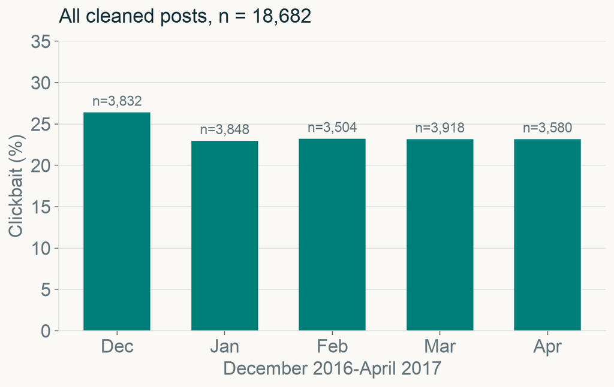

**23.8% clickbait** in the cleaned Webis-17 pilot.

Median length is **10 words** for clickbait teasers and **12** for the other teasers.

**Zero exact overlaps** of IDs, normalized teasers or normalized titles across main partitions.

Near-duplicate audit pending.

## Train, validate, test

### Train

Dec 2016–Feb 2017

**11,184 posts**

Fit TF-IDF, cue scaling and classifiers

### Validate

Mar 2017

**3,918 posts**

Select regularization by macro-F₁

### Test

Apr 2017

**3,580 posts**

23.2% clickbait · compare the same posts

**Primary** · Macro-F₁ and paired C−B

Also measured in April · Positive-class scores, average precision and Brier score

## April results

April 2017 test · 3,580 posts · 830 positive (23.2%)

Macro-F₁

00.250.500.751.00

**A · TF-IDF**

0.7479

**B · MiniLM**

0.7111

**C · MiniLM + cues**

0.7374

Paired C−B

+2.63

percentage points

One window  
Paired interval pending

Same test posts · Saved predictions · Reproduced in a fresh environment

April was held out from fitting and selection in this run. An earlier pilot had already scored April.

## What changed on individual posts?

Two model disagreements · April 2017 test · [Webis-17 (Potthast et al., 2018)](https://aclanthology.org/C18-1127/) · CC BY 4.0

### Corrected error

> “These cities will overthrow Silicon Valley as the new centers for tech in coming years:”

**Corpus label**

Clickbait

**B**

Non-clickbait

**C**

Clickbait

### Introduced false positive

> “Here are the best TV shows and movies coming to Netflix, Amazon and more in April”

**Corpus label**

Non-clickbait

**B**

Non-clickbait

**C**

Clickbait

In April, C corrected **162** B errors and introduced **80**.

## What will test H1–H4?

Planned · full study

**H1 · Cue gain**

Paired bootstrap interval for April C−B

**H2 · Persistence**

February, March and April tests plus three article-grouped random diagnostics

**H3 · Cue families**

Four family removals and at least 20 categorized errors

### H4 · Article relations Secondary experiment

Same rows, teaser, title and 96-word-token article excerpt

**C<sub>ctx</sub>** → **D<sub>ctx</sub>**

**Add three cues** · Content-word overlap, missing teaser entities, embedding similarity

[Title–body interaction: Wu et al. (2020)](https://aclanthology.org/2020.ccl-1.106/)

Compare probability calibration with test prevalence in view.

## Before the Phase 2 checkpoint

### Data audit

Review near-duplicates across partitions.

### Experiment plan

Second method class under selection. Fine-tuned DistilBERT is one candidate.

**External diagnostic** · Webis-16 after schema, label and overlap checks

**Optional** · Jeff-Qwen3.5 and YTClickbait21K titles

How should we validate near-duplicate detection when related articles have different titles?

## Appendix · Twelve teaser cues

### Referential withholding

- **Initial pointer** · First token matches the pointer list.
- **Indefinite referents** · Share of tokens matching the indefinite list.
- **Delayed revelation** · A listed phrase occurs, such as “here's why”.

### Audience involvement

- **Direct address** · Share of tokens matching the address list.
- **Action invitation** · Listed opening token or opening “find out”.
- **Question hook** · Listed opening question token and a question mark.

### Affective and narrative framing

- **Surprise** · Share of tokens matching the surprise list.
- **Epistemic distance** · Share matching cautious terms such as “reportedly”.
- **Narrative reversal** · A listed reversal phrase occurs.

### Specificity and presentation

- **Numbered payoff** · Integer 1–99 in the first two tokens, then a payoff word within four tokens.
- **Attention punctuation** · Exclamation marks, question marks and ellipsis events per character, capped at 1.
- **Referent–anchor imbalance** · P / (P + A + 1), where P counts listed referents and A counts non-initial capitalized tokens excluding all-caps.

## Appendix · April metrics and compute

April 2017 test · 3,580 posts · 830 clickbait (23.2%)

| System | Macro-F₁ | Clickbait precision | Clickbait recall | Clickbait F₁ | Average precision | Brier |
| --- | --- | --- | --- | --- | --- | --- |
| A · TF-IDF | **0.7479** | 0.615 | 0.610 | 0.612 | 0.650 | **0.132** |
| B · MiniLM | 0.7111 | 0.498 | 0.707 | 0.584 | 0.652 | 0.160 |
| C · MiniLM + cues | 0.7374 | 0.533 | 0.741 | **0.620** | **0.674** | 0.151 |

**Also available** · April confusion matrices and saved probabilities.

**Planned** · Reliability diagrams, paired uncertainty and comparison with each test's prevalence.

**Measured PoC cost** · 8.024 s runner, including 0.582 s April inference, and 718.6 MiB peak process RSS. Apple M3 Max, thread limits 4, cached embeddings.

Runner time includes reconciliation, fitting, scoring and export after imports. Downloads and embedding generation are excluded.

## Appendix · Selected literature evidence

| Work | Method and input | Corpus and evaluation | Published measure |
| --- | --- | --- | --- |
| [Potthast et al. (2016)](https://downloads-cf.webis.de/publications/papers/potthast_2016b.pdf) | Random forest, explicit cues | Webis-16 · random 2:1 split, test | ROC-AUC 0.79 |
| [Biyani et al. (2016)](https://ojs.aaai.org/index.php/AAAI/article/view/9966) | Boosted trees, title/body/URL | Yahoo news · 3,000 train, 1,073 test | Weighted F₁ 0.749, positive F₁ 0.603 |
| [Zhou (2017)](https://arxiv.org/abs/1710.05364) | Attention and recurrent network, post | Clickbait Challenge 2017 · official test | Strength MSE 0.033 |
| [Indurthi et al. (2020)](https://aclanthology.org/2020.coling-main.425/) | Transformers and regression, post | Clickbait Challenge 2017 · official test | Strength MSE 0.0242 |
| [Wu et al. (2020)](https://aclanthology.org/2020.ccl-1.106/) | Style and co-attention, title/body | Challenge data · 2,495 development items used as test | Positive F₁ 0.733 |
| [Broscoțeanu and Ionescu (2023)](https://aclanthology.org/2023.findings-emnlp.640/) | Contrastive Ro-BERT, article | RoCliCo · 1,507 publisher-disjoint test rows | Macro-F₁ 0.9199 |
| [Michaluk et al. (2026)](https://arxiv.org/html/2602.18171v1#S4.SS4) | Embeddings and cues, headline | Balanced mixed sources · stratified 80/10/10, test | F₁ 0.864–0.909, averaging unspecified |

MSE is mean squared error. Input fields, targets, evaluation splits and F₁ averaging differ across studies.